# Damage due to Weather Events

Himank Jain

March 15, 2019

# Sypnosis:Analysis of Weather Events.

The source of the data is NOAA Storm Database. The Analysis tries to deduce the effect of multiple weather events on Public Health and Economy. Weather events cause massive health hazards and economic problems every year and it’s important to understand their nature and characterstics. This analysis involves data visualization for studying the effects of major weather events on both puclic health and economy. The health effects include fatalities and inuries and economic factors include property damage and crop damage.

# Data Processing:

## Loading required Packages

## Reading the data

```r
storm<-fread("repdata_data_StormData.csv.bz2",sep=",",header=TRUE)
```

## Exploratory Analysis

```r
storm<-tbl_df(storm)
summary(storm)
```

```
##     STATE__       BGN_DATE           BGN_TIME          TIME_ZONE
##  Min.   : 1.0   Length:902297      Length:902297      Length:902297
##  1st Qu.:19.0   Class :character   Class :character   Class :character
##  Median :30.0   Mode  :character   Mode  :character   Mode  :character
##  Mean   :31.2
##  3rd Qu.:45.0
##  Max.   :95.0
##
##      COUNTY       COUNTYNAME           STATE              EVTYPE
##  Min.   :  0.0   Length:902297      Length:902297      Length:902297
##  1st Qu.: 31.0   Class :character   Class :character   Class :character
##  Median : 75.0   Mode  :character   Mode  :character   Mode  :character
##  Mean   :100.6
##  3rd Qu.:131.0
##  Max.   :873.0
##
##    BGN_RANGE          BGN_AZI           BGN_LOCATI          END_DATE
##  Min.   :   0.000   Length:902297      Length:902297      Length:902297
##  1st Qu.:   0.000   Class :character   Class :character   Class :character
##  Median :   0.000   Mode  :character   Mode  :character   Mode  :character
##  Mean   :   1.484
##  3rd Qu.:   1.000
##  Max.   :3749.000
##
##    END_TIME           COUNTY_END COUNTYENDN       END_RANGE
##  Length:902297      Min.   :0    Mode:logical   Min.   :  0.0000
##  Class :character   1st Qu.:0    NA's:902297    1st Qu.:  0.0000
##  Mode  :character   Median :0                   Median :  0.0000
##                     Mean   :0                   Mean   :  0.9862
##                     3rd Qu.:0                   3rd Qu.:  0.0000
##                     Max.   :0                   Max.   :925.0000
##
##    END_AZI           END_LOCATI            LENGTH              WIDTH
##  Length:902297      Length:902297      Min.   :   0.0000   Min.   :   0.000
##  Class :character   Class :character   1st Qu.:   0.0000   1st Qu.:   0.000
##  Mode  :character   Mode  :character   Median :   0.0000   Median :   0.000
##                                        Mean   :   0.2301   Mean   :   7.503
##                                        3rd Qu.:   0.0000   3rd Qu.:   0.000
##                                        Max.   :2315.0000   Max.   :4400.000
##
```

[output cut: 25 more lines]

```
##  Min.   :-14451   Min.   :   0   Min.   :-14455   Length:902297
##  1st Qu.:  7247   1st Qu.:   0   1st Qu.:     0   Class :character
##  Median :  8707   Median :   0   Median :     0   Mode  :character
##  Mean   :  6940   Mean   :1452   Mean   :  3509
##  3rd Qu.:  9605   3rd Qu.:3549   3rd Qu.:  8735
##  Max.   : 17124   Max.   :9706   Max.   :106220
##                   NA's   :40
##      REFNUM
##  Min.   :     1
##  1st Qu.:225575
##  Median :451149
##  Mean   :451149
##  3rd Qu.:676723
##  Max.   :902297
##
```

```r
str(storm)
```

```
## Classes 'tbl_df', 'tbl' and 'data.frame':    902297 obs. of  37 variables:
##  $ STATE__   : num  1 1 1 1 1 1 1 1 1 1 ...
##  $ BGN_DATE  : chr  "4/18/1950 0:00:00" "4/18/1950 0:00:00" "2/20/1951 0:00:00" "6/8/1951 0:00:00" ...
##  $ BGN_TIME  : chr  "0130" "0145" "1600" "0900" ...
##  $ TIME_ZONE : chr  "CST" "CST" "CST" "CST" ...
##  $ COUNTY    : num  97 3 57 89 43 77 9 123 125 57 ...
##  $ COUNTYNAME: chr  "MOBILE" "BALDWIN" "FAYETTE" "MADISON" ...
##  $ STATE     : chr  "AL" "AL" "AL" "AL" ...
##  $ EVTYPE    : chr  "TORNADO" "TORNADO" "TORNADO" "TORNADO" ...
##  $ BGN_RANGE : num  0 0 0 0 0 0 0 0 0 0 ...
##  $ BGN_AZI   : chr  "" "" "" "" ...
##  $ BGN_LOCATI: chr  "" "" "" "" ...
##  $ END_DATE  : chr  "" "" "" "" ...
##  $ END_TIME  : chr  "" "" "" "" ...
##  $ COUNTY_END: num  0 0 0 0 0 0 0 0 0 0 ...
```

[output cut: 24 more lines]

## 1) PUBLIC HEALTH:Fatalities and Injuries

```r
stormpop<-subset(storm,select = c("EVTYPE","FATALITIES","INJURIES"))
fatalities<-aggregate(data=stormpop,FATALITIES~EVTYPE,FUN = sum)
fatalities<-fatalities[order(fatalities$FATALITIES,decreasing = TRUE),]
injuries<-aggregate(data=stormpop,INJURIES~EVTYPE,FUN=sum)
injuries<-injuries[order(injuries$INJURIES,decreasing = TRUE),]
topfatalities<-fatalities[1:20,]
topinjuries<-injuries[1:20,]
```

##Plotting Most effective Weather Events vs Fatalities and Most effective Weather Events and Injuries.

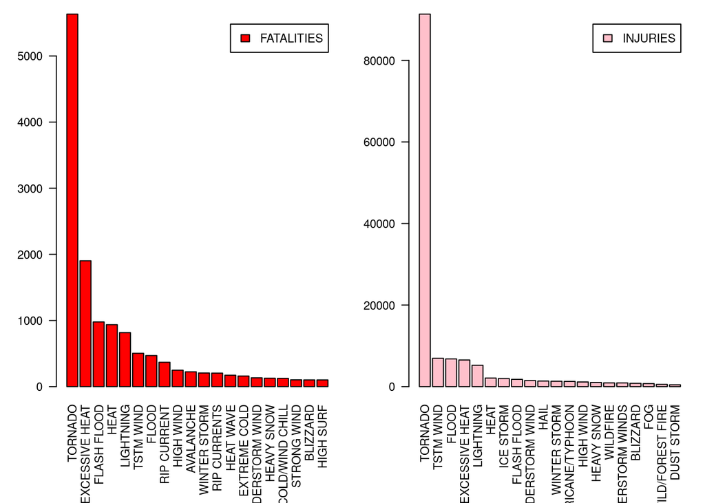

```r
par(mfrow = c(1, 2), las = 2,cex=0.7,font.lab=2,mar=c(8,4,1,1))
barplot(topfatalities$FATALITIES,names.arg=topfatalities$EVTYPE,col="red",legend.text = "FATALITIES")
barplot(topinjuries$INJURIES,names.arg = topinjuries$EVTYPE,col="pink",legend.text = "INJURIES")
```

# Aggregating Fatilities and Injuries:

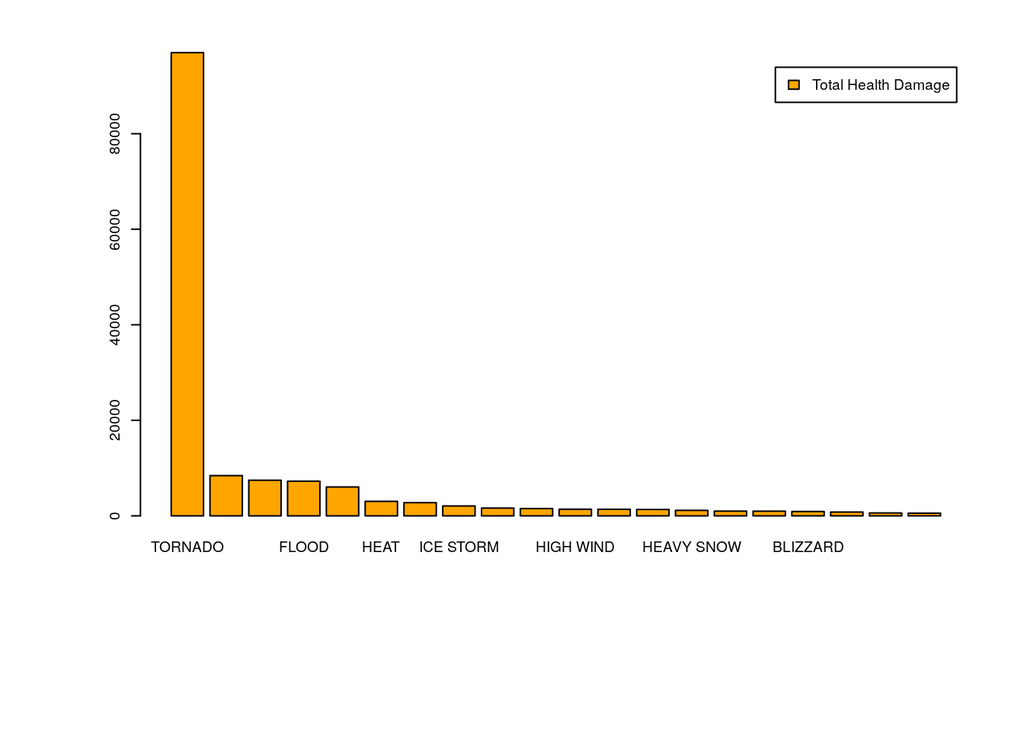

```r
healthdmg<-merge(fatalities,injuries,by="EVTYPE")
healthdmg$dmg<-healthdmg$FATALITIES+healthdmg$INJURIES
healthdmg<-healthdmg[order(healthdmg$dmg,decreasing = TRUE),]
tophealthdmg<-healthdmg[1:20,]
par(mfrow=c(1,1),mar=c(12,8,3,3),cex=0.6)
barplot(tophealthdmg$dmg,names.arg = tophealthdmg$EVTYPE,col="orange",legend.text = "Total Health Damage")
```

- We can Observe that most of the Public health effects (fatalities and injuries) are caused by Tornadoes.

## 2) Economic Consequences:

```r
stormprop<-subset(storm,select=c("EVTYPE","PROPDMG","CROPDMG"))
propdmg<-aggregate(data=stormprop,PROPDMG~EVTYPE,FUN=sum)
cropdmg<-aggregate(data=stormprop,CROPDMG~EVTYPE,FUN=sum)
propdmg<-propdmg[order(propdmg$PROPDMG,decreasing = TRUE),]
cropdmg<-cropdmg[order(cropdmg$CROPDMG,decreasing=TRUE),]
topprop<-propdmg[1:20,]
topcrop<-cropdmg[1:20,]
```

## Visualizing Significant Weather Events vs Property Damage and Significant Weather Events vs Crop Damage:

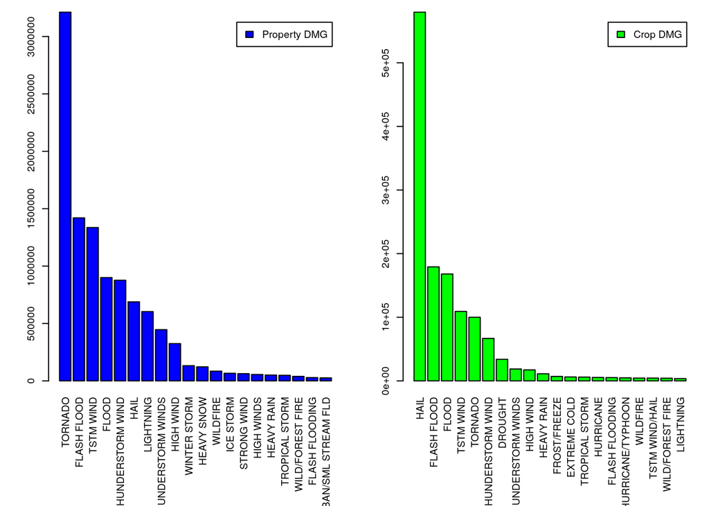

```r
par(mfrow = c(1, 2), las = 3,cex=0.6,font.lab=2,mar=c(10,4,1,1))
barplot(topprop$PROPDMG,names.arg = topprop$EVTYPE,col="blue",legend.text = "Property DMG")
barplot(topcrop$CROPDMG,names.arg = topcrop$EVTYPE,col="green",legend.text = "Crop DMG")
```

## Aggregating Property and Crop Damages:

```r
economicdmg<-merge(propdmg,cropdmg,by="EVTYPE")
economicdmg$ecodmg<- economicdmg$PROPDMG+economicdmg$CROPDMG
economicdmg<-economicdmg[order(economicdmg$ecodmg,decreasing = TRUE),]
topecodmg<-economicdmg[1:20,]
```

## Significant Weather Events vs Economic Loss

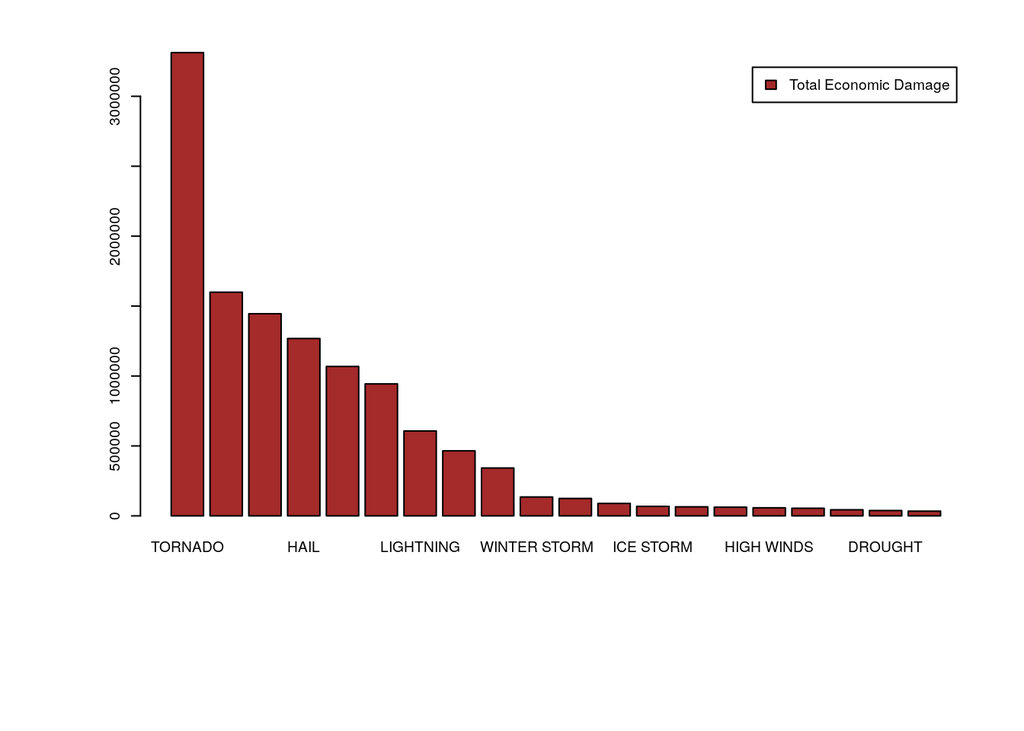

```r
par(mfrow=c(1,1),mar=c(12,8,3,3),cex=0.6)
barplot(topecodmg$ecodmg,names.arg=topecodmg$EVTYPE,col="brown",legend.text = "Total Economic Damage")
```

# Results: